# R Notebook

## Weekend Homework - stats

```r
library(tidyverse)
library(janitor)
library(infer)
```

```r
players <- read_csv("data/players.csv")
players <- clean_names(players)
```

1. The overall variable is of primary interest to the NFA. Perform a full analysis of the distribution of the overall variable in the sample. Use the tools you learned this week to quantify centrality, spread, modality and normality of this variable, making an appropriate choice of metric for each.

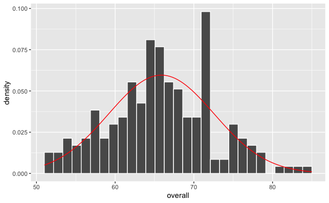

```r
players %>%
  ggplot +
  aes(x = overall) +
  geom_histogram(aes(y = ..density..), col = "white") +
  stat_function(
    fun = dnorm,
    args = list(
      mean = mean(players$overall),
      sd = sd(players$overall)
    ),
    col = "red")
```

[figure not shown]

```r
players %>%
  select(overall) %>%
  skim()
```

```
── Data Summary ────────────────────────
                           Values
Name                       Piped data
Number of rows             200
Number of columns          1
_______________________
Column type frequency:
  numeric                  1
________________________
Group variables            None

── Variable type: numeric ──────────────────────────────────────────────────────────────
  skim_variable n_missing complete_rate  mean    sd    p0   p25   p50   p75  p100 hist
1 overall               0             1  65.9  6.69    51    62    66  70.2    85 ▂▆▇▃▁
```

The mean and the median of the data are v close - suggesting that the data are fairly symmetrical

From these first plots, and the 5 number summary, it appears that the distribution has some outliers to the right - will try to check if this has an impact on the distribution, checking it isn’t right skewed

```r
skewness(players$overall)
```

```
[1] 0.08664496
```

What about modality?

| mode |
| --- |
| 66 |

Now check the normality of the data - do so by using bootstrapping

| 2.5% | 97.5% |
| --- | --- |
| 64.97 | 66.805 |

The NFA have asked SoccerIntel to tell them which of the playing style metrics is most strongly correlated with overall rating, so they can tell individual clubs which component of playing style to focus on in their training regimes. Calculate these correlations and make a recommendation.

```
data in column(s) 'height', 'weight', 'preferred_foot', 'value', 'wage', 'release_clause' are not numeric and were ignored
```

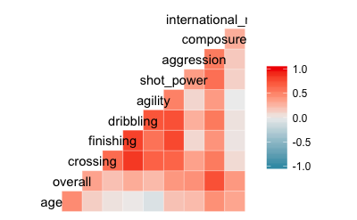

```r
players %>%
  ggcorr()
```

Strongest correlation is between overall and composure: 0.74

SoccerIntel want to properly detail the relationship between the most strongly correlated playing style metric from above (hereafter, we’ll just call this the ‘style metric’) with the overall rating. Perform simple linear regression to quantify the relationship. If the clubs manage to raise the style metric by 5 points on average by improvement in training, how would you expect the overall rating to change? Can you provide a range of likely values for this slope?

| term | estimate | std_error | statistic | p_value |
| --- | --- | --- | --- | --- |
| (Intercept) | 39.8044234 | 1.71941838 | 23.14993 | 3.098814e-58 |
| composure | 0.4474099 | 0.02899319 | 15.43155 | 8.516632e-36 |

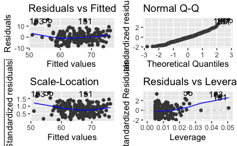

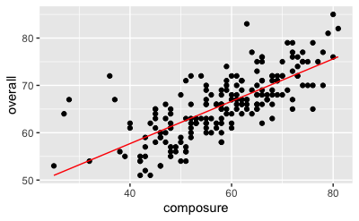

Try to fit a linear model by bootstrapping

| 2.5% | 97.5% |
| --- | --- |
| 0.3722846 | 0.5254183 |

The NFA would like to know the proportion of players in the country who are ‘internationally significant’ (defined as having an international_reputation greater than 1). Determine this proportion for the country, with a suitable measure of uncertainty in the estimate.

[output not shown]

```r
point_est_mean_int_sig

ci_95
```

| 2.5% | 97.5% |
| --- | --- |
| 0.025 | 0.09 |

SoccerIntel let you know that the NFA are keen to highlight an ‘increase in the proportion of internationally significant players in the country’ in a forthcoming media release. Last year’s proportion was 0.04. Do you think this optimistic appraisal is statistically justifiable?

```r
  #alpha: 0.95


  #H0: Proportion of int_significant players is at 0.04 or less

      #proportion <= 0.04

  #HA: proportion > 0.04
```

| p_value |
| --- |
| 0.4328 |

SoccerIntel let you know that the NFA are keen to highlight an ‘increase in the proportion of internationally significant players in the country’ in a forthcoming media release. Last year’s proportion was 0.04. Do you think this optimistic appraisal is statistically justifiable?

No - the optimistic appraisal is not justified.

Above I undertook a hypothesis test to assess the claim, and found that the observed change of internationally significant players was not significantly different from the null distribution to warrant the above conclusion. First, I set a significance level of 0.95 - meaning that I would tolerate a type I error (a false positive result), one in 20 times. In other words, I was willing to falsely claim that there had been an increase in internationally significant players in 1 in 20 simulations of the model. I then set out my null hypothesis, which was that the level of internationally significant players had stayed the same (0.04), or had declined. The alternative hyporthesis was therefore that the numebr of internationally significant players had gone up, and was above 0.04. Assuming the null hypothesis to be true (of int_significant proportion to = 0.04) I then calculated the null distribution, using bootstrapping. I then placed the observed statistic of int_significant proportion on this null distribution - and showed that, although the observed stat was indeed higher than that of the previous year (0.05), the change was not statistically significant. With a p-value of 0.4328, the point estimate fails to pass my significance threshold of alpha < 0.05, and thus is insufficiently different from the null hypothesis to claim an increase. This can be expressed differently by noting that the confidence 95% interval for the observed proportion of internationally significant players in the sample included last year’s figure of 0.04, meaning that we cannot claim with 95% confidence that there has been an increase in int_significant players. The variation seen in our sample may be due to chance alone, and there may indeed have been a drop in the number of int_significant players across the population.